# Practical Task 2

Author

Vasyl Lukashchuk

Published

September 20, 2025

# Challenges

**Data files**: seq_reads  
Contains three short read .fasta data files with sequences of various quality

**Challenge #1**: DS1, DS2 are synthetic DNA data sets. Build two tools (R or python3) to visualize and analyze data quality.  
1. Plot DNA length v. Q, length v. number of N ambiguities, Q v. N.  
2. Generate a heatmap comparing the two data sets.

**Challenge #2**: SRR14149060 is from a [breast cancer study](https://www.ncbi.nlm.nih.gov/sra/?term=SRR14149060).  
1. Analyze read lengths: are these human reads? To what do they target?  
2. Generate concept for a rapid mapping of reads to the human genome to assess quality and distribution.

# Challenge #1

## Extracting data from FASTA files

### Importing third_party librarties

```r
library("tidyverse")
library("patchwork")
```

### Saving relative paths to data files

```r
DS1_path <- "./seq_reads/DS1.fasta"
DS2_path <- "./seq_reads/DS2.fasta"
```

### Converting FASTA files to tibbles

```r
fasta_as_tibble <- function(path_to_fasta) {
  # Get a list of strings representing sequences and their respective headers
  sample_char_list <- read_file(path_to_fasta) |>
    str_remove("^>") |>
    str_replace_all("\n", "") |>
    str_split(">")

  sample_char_list <- sample_char_list[[1]] # Split function returns a layered
  # list, so access the data in the layer 1

  # Extract values we need for analysis
  # I used Gemini and Regex101 to write and test regular expressions
  id <- str_extract(sample_char_list, '^\\S+')
  set <- str_extract(sample_char_list, '(?<=set=).*(?=\\sq)')
  q <- str_extract(sample_char_list, '(?<=q=).*(?=\\sl)')
  read <- str_extract(sample_char_list, '[ATGCN]*$')

  # Create a tibble with a quality column converted to numeric from char
  resulting_tibble <- tibble(
  ID = id,
  Set = set,
  Quality = as.numeric(q),
  Seq_read = read
)

  # Add a length column by calculating length of each read
  resulting_tibble <- resulting_tibble |>
    mutate(Length = str_length(Seq_read))

  # Add a column containing a number of occurences of N in each read
  resulting_tibble <- resulting_tibble |>
    mutate(N_number = str_count(Seq_read, "N"))

  return(resulting_tibble)
}
```

```r
DS1 <- fasta_as_tibble(DS1_path)
DS2 <- fasta_as_tibble(DS2_path)
```

## Plotting the relationships between numerical variables

### Adding a quality range column to datasets

```r
categorize_by_q <- function(data) {
  # Plotting a relationship between 2 discreet variables doesn't produce
  # informative plots, so I decided to add a categorical data column to be
  # represented as different fill on a histogram
  categorized_data <- data |>
  mutate(Qscore_range = case_when(
    Quality <= 10 ~ "0-9",
    Quality > 10 & Quality <= 20 ~ "10-20",
    Quality > 20 & Quality <= 30 ~ "21-30",
    Quality > 30 ~ "31-36"
  ))
  return(categorized_data)
}

DS1 <- categorize_by_q(DS1)
DS2 <- categorize_by_q(DS2)
```

### Read length vs Qscore plots

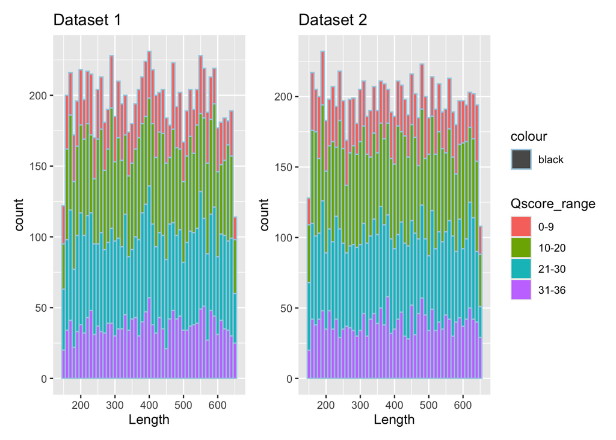

```r
p1_len_q <- ggplot(DS1, aes(x = Length, fill = Qscore_range, color = "black")) +
  geom_histogram(binwidth = 10) + scale_color_brewer(palette="Paired") +
  labs(title = "Dataset 1")

p2_len_q <- ggplot(DS2, aes(x = Length, fill = Qscore_range, color = "black")) +
  geom_histogram(binwidth = 10) + scale_color_brewer(palette="Paired") +
  labs(title = "Dataset 2")

p1_len_q + p2_len_q + plot_layout(guides = "collect")
```

The majority of reads have quality scores between 10 and 30 for both datasets. A Q-score of 10 indicates a 90 % probability of an accurate base call, whereas a score of 20 represents a 99 % probability. Only a minor fraction of reads in red contain a relatively big number of errors.

### Factorizing number of N

```r
# Range of N occurences isn't as broad as in case of quality scores,
# so I factorized this variable for mapping it to fill aesthetic
DS1$N_number_factor <- factor(DS1$N_number)
DS2$N_number_factor <- factor(DS2$N_number)
```

### Length v. number of ambiguities (N) plots

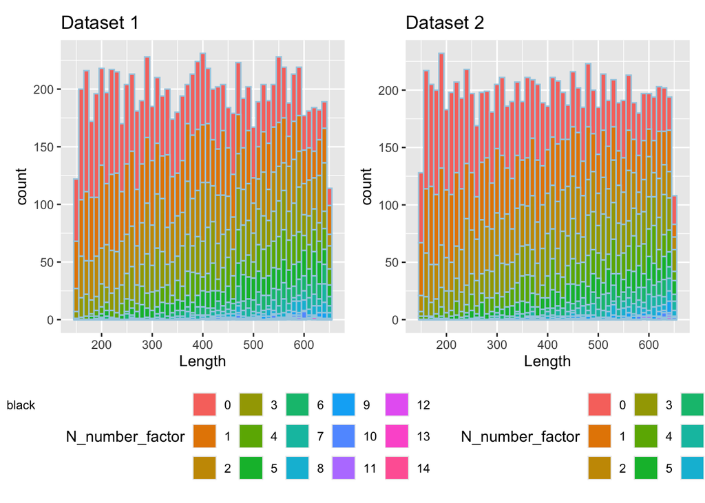

```r
p1_len_n <- ggplot(DS1, aes(x = Length, fill = N_number_factor, color = "black")) +
  geom_histogram(binwidth = 10) + scale_color_brewer(palette="Paired") +
  labs(title = "Dataset 1")

p2_len_n <- ggplot(DS2, aes(x = Length, fill = N_number_factor, color = "black")) +
  geom_histogram(binwidth = 10) + scale_color_brewer(palette="Paired") +
  labs(title = "Dataset 2")

p1_len_n + p2_len_n + plot_layout(guides = "collect") &
  theme(legend.position = "bottom")
```

Number of ambiguities increases with the read length

### Q vs N plots

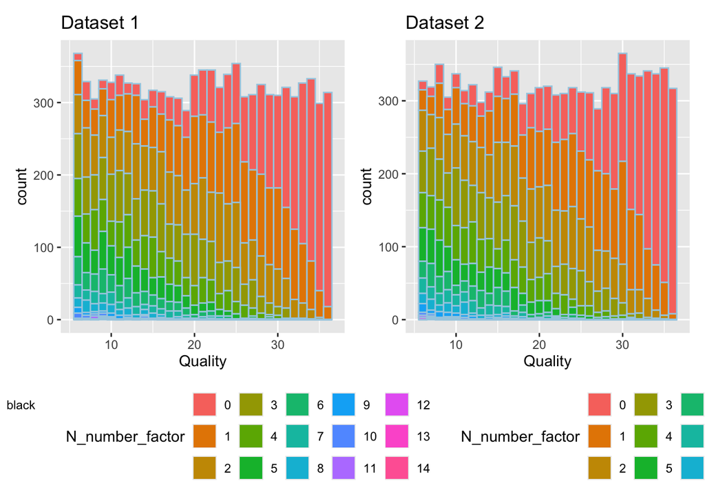

```r
p1_q_n <- ggplot(DS1, aes(x = Quality, fill = N_number_factor, color = "black")) +
  geom_histogram(binwidth = 1) + scale_color_brewer(palette="Paired") +
  labs(title = "Dataset 1")

p2_q_n <- ggplot(DS2, aes(x = Quality, fill = N_number_factor, color = "black")) +
  geom_histogram(binwidth = 1) + scale_color_brewer(palette="Paired") +
  labs(title = "Dataset 2")

p1_q_n + p2_q_n + plot_layout(guides = "collect") &
  theme(legend.position = "bottom")
```

The higher the Qscore is - the less ambiguities there are in a read.

## Generating a heatmap comparing the two data sets

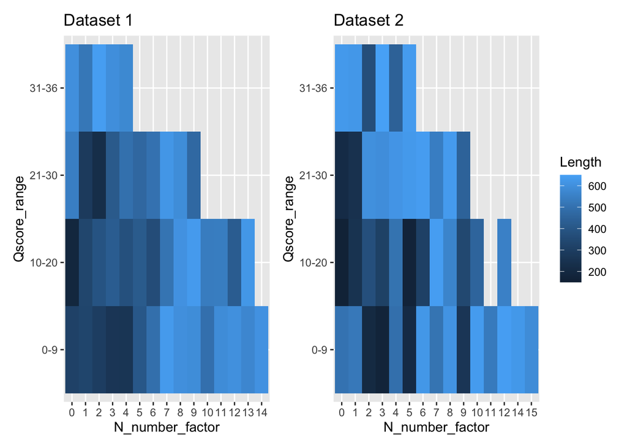

```r
    hm1 <- ggplot(DS1, aes(x = N_number_factor, y = Qscore_range,
                           fill = Length)) + geom_tile() +
                            labs(title = "Dataset 1")
    hm2 <- ggplot(DS2, aes(x = N_number_factor, y = Qscore_range,
                          fill = Length)) + geom_tile() +
                          labs(title = "Dataset 2")
    hm1 + hm2 + plot_layout(guides = "collect")
```

# Challenge #2

## Analyzing read length

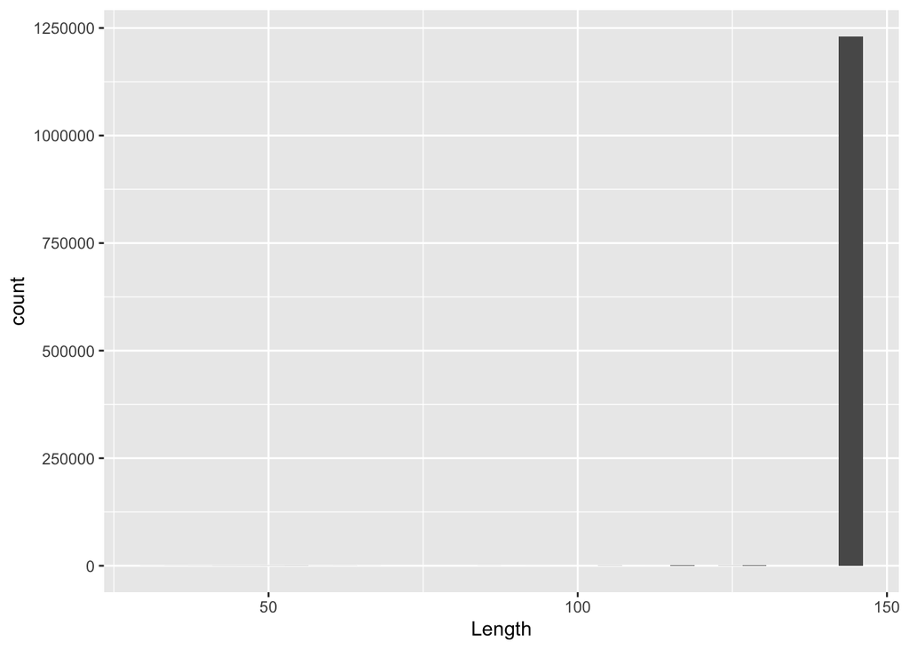

```r
sample_char_list <- read_file("./seq_reads/SRR14149060.fasta") |>
    str_remove("^>") |>
    str_replace_all("\n", "") |>
    str_split(">")

  sample_char_list <- sample_char_list[[1]] # Split function returns a layered
  # list, so access the data in the layer 1

  read <- str_extract(sample_char_list, '[ATGCN]*$')

  # Create a tibble
  breast_cancer_study <- tibble(
  Seq_read = read
)

  # Add a length column by calculating length of each read
  breast_cancer_study <- breast_cancer_study |>
    mutate(Length = str_length(Seq_read))

  ggplot(breast_cancer_study, aes(x = Length)) + geom_histogram()
```

## A concept for a rapid mapping of reads to the human genome to assess quality and distribution

1. Remove adapter sequences from raw reads, perform a quality check and filter oout low quality reads.
2. Obtain, decompress and index a reference genome
3. Perform a paired end allignment of reads to reference.
4. Obtain sequence alignment/map format (SAM) files
5. Convert SAM files to BAM (binary form of the same data) for more efficient storage
6. Perform variant calling and save results in VCF format
7. Filter variants by depth, occurence frequency, perform statistical test on allele frequencies
8. Check for PCR duplication issues and contamination

Insights on file formats and how to work with them were obtained here: https://speciationgenomics.github.io/readsExploration/